# The Importance of Preprocessing in Data Science

## Introduction

When performing any type of machine learning assessment, data preprocessing is an absolute necessity. Whether dealing with text data by removing unnecessary white spaces, punctuation marks, or special characters; or dealing with numeric data by scaling and centering features, data preprocessing is an essential process in any machine learning assessment.

For the purposes of this assessment, we will be using the wine quality data set to demonstrate why proper scaling and centering of numeric data is essential in machine learning. We will be fitting a k-Nearest Neighbors algorithm to further explicate the need for proper normalization of numeric data.

## Data

kNN models are a basic lazy learning technique that attempts to classify samples based on its position in a dimensional features space, relative the plotted labels of known examples. The k in kNN refers to how many neighbors in the feature space to consider. The mode of the nearby class labels informs the model how to classify the unknown observation.

```python
from IPython.display import Image
Image(url= 'http://36.media.tumblr.com/d100eff8983aae7c5654adec4e4bb452/tumblr_inline_nlhyibOF971rnd3q0_500.png')
```

[figure not shown]

Above is a basic visual overview of which samples are considered when adjusting for the number of neighbors.

## kNN

To begin our exploration of data preprocessing, we will use Python to examine the distribution of our numeric predictor features through visualization using histograms:

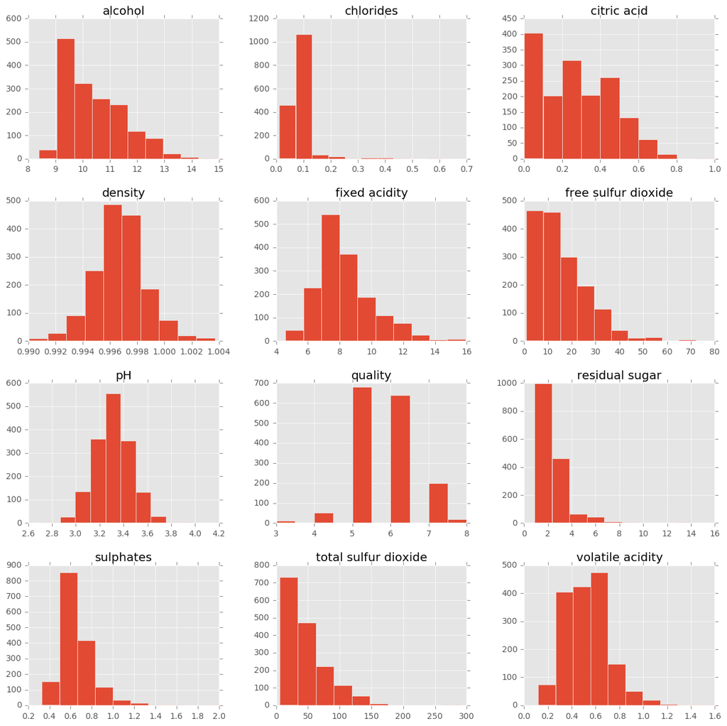

```python
import pandas as pd
%matplotlib inline
import matplotlib.pyplot as plt
plt.style.use('ggplot')
df = pd.read_csv('http://archive.ics.uci.edu/ml/machine-learning-databases/wine-quality/winequality-red.csv ' , sep = ';')
X = df.drop('quality' , 1).values # drop target variable
y1 = df['quality'].values
pd.DataFrame.hist(df, figsize = [15,15]);
```

Algorithms that rely on numeric distance are going to be highly susceptible to variables with large ranges, which may or may not be an outlier in the data. This biases the model to those features.

Further, the varying ranges of values for different variables also tells us that each feature is not measured along the same scale.

Before we can continue we will take this opporunity to assign our wine quality class label:

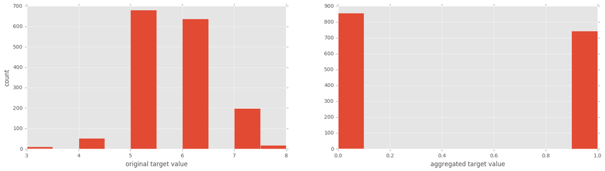

```python
y = y1 <= 5 # is the rating <= 5?
# plot histograms of original target variable
# and aggregated target variable
plt.figure(figsize=(20,5));
plt.subplot(1, 2, 1 );
plt.hist(y1);
plt.xlabel('original target value')
plt.ylabel('count')
plt.subplot(1, 2, 2);
plt.hist(y)
plt.xlabel('aggregated target value')
plt.show()
```

In order to illustrate the importance of scaling numeric features, we will first create a kNN model without normalizing the data for comparison.

Additionally we will create train and test sets for validation. For evaluating model performance, we will use accuracy as our metric, which is simply the number of observations correctly classified out of the total observations considered:

```python
from sklearn.cross_validation import train_test_split
X_train, X_test, y_train, y_test = train_test_split(X, y, test_size=0.2, random_state=42)

from sklearn import neighbors, linear_model
knn = neighbors.KNeighborsClassifier(n_neighbors = 5)
knn_model_1 = knn.fit(X_train, y_train)
print('k-NN accuracy for test set: %f' % knn_model_1.score(X_test, y_test))
```

```
k-NN accuracy for test set: 0.612500
```

```python
from sklearn.metrics import classification_report
y_true, y_pred = y_test, knn_model_1.predict(X_test)
print(classification_report(y_true, y_pred))
```

```
             precision    recall  f1-score   support

      False       0.66      0.64      0.65       179
       True       0.56      0.57      0.57       141

avg / total       0.61      0.61      0.61       320
```

## Scaling

```python
from sklearn.preprocessing import scale
Xs = scale(X)
from sklearn.cross_validation import train_test_split
Xs_train, Xs_test, y_train, y_test = train_test_split(Xs, y, test_size=0.2, random_state=42)
knn_model_2 = knn.fit(Xs_train, y_train)
print('k-NN score for test set: %f' % knn_model_2.score(Xs_test, y_test))
print('k-NN score for training set: %f' % knn_model_2.score(Xs_train, y_train))
y_true, y_pred = y_test, knn_model_2.predict(Xs_test)
print(classification_report(y_true, y_pred))
```

```
k-NN score for test set: 0.712500
k-NN score for training set: 0.814699
             precision    recall  f1-score   support

      False       0.72      0.79      0.75       179
       True       0.70      0.62      0.65       141

avg / total       0.71      0.71      0.71       320
```

## Conclusion

Assessing the performance of our model against scaled data, it is easy to see the importance of such data preprocessing prior to model fitting. Numeric features with a large range (min-max) in values often skew models such that outlier values are either discounted entirely or cause the model to overfit a value which may simply be noise.